# Trends in Human Papillomavirus (HPV) Vaccination in the United States, 2013-2023

BMIN 5030 Final Project

Author

Lee Krobock

## Overview

A relatively recent development in preventative medicine, the human papillomavirus (HPV) vaccine confers immunity to multiple oncogenic strains of HPV. Studies have demonstrated decreased risks of head, neck, and cervical cancers, and cervical dysplasia in vaccinated individuals.<sup>1</sup> Despite this, HPV vaccination has proven to be a challenging task in practice, with multiple changes to vaccine recommendations since its initial release and notable vaccine hesitancy, particularly early in its history and among parents of children and adolescents. The goal of this project is to analyze questionnaire data from the National Health and Nutrition Examination Survey (NHANES) from 2013 to 2023 to describe trends in HPV vaccine coverage and vaccination practices in the United States.

[Final Project GitHub repository](https://github.com/lkrobock/BMIN-5030-Final-Project)

## Introduction

The first vaccine against human papillomavirus, Gardasil 4vHPV, was licensed for use by the U.S. Food and Drug Administration (FDA) in June 2006, followed by official recommendations for use by the Advisory Committee on Immunization Practices (ACIP) published in March 2007.<sup>2</sup> This quadrivalent vaccine provided protection against four strains of HPV and was initially recommended only for female patients between the ages of 9 and 26 years.<sup>2</sup> Subsequently, in 2010, these recommendations were expanded to include males between ages 9 and 26.<sup>3</sup> Following the 2015 FDA approval of a nonavalent HPV vaccine, which provided protection against an additional five disease-associated strains, the ACIP updated its recommendations to consider two appropriately-timed doses of HPV vaccine to be a completed series in patients who received the first dose between ages 9 and 14.<sup>4</sup> The most recent update to HPV immunization guidelines recommends “shared clinical decision-making” to guide vaccination in adults between ages 27 and 45 years old, and notes that HPV vaccines are not licensed for use in adults over age 45.<sup>5</sup>

There are significant and well-described benefits to HPV vaccination– studies have demonstrated decreased risk of strain-specific HPV infection and associated growths, dysplasias, and cancers.<sup>1,6</sup> Furthermore, Ellingson et al. noted in their systematic review that multiple studies suggest increased vaccine effectiveness with younger patient age at vaccination.<sup>6</sup> In practice, however, clinicians have encountered challenges in implementing HPV vaccination as a standard preventative care practice. For this project, I spoke with five family medicine and primary care clinicians to better understand their experiences in practice with HPV vaccination. In addition to slow shifts in practice following official recommendations and guideline updates, providers describe patient hesitancy early in the history of the HPV vaccine, related to potential side effects, adverse effects, and concerns about children and adolescents becoming sexually active earlier following vaccination. In one clinician’s experience, it was not until the link between HPV and cancer became more widely understood by the public and HPV vaccination was marketed toward adults in addition to pediatric patients that it gained traction with the public.

Preventative healthcare, including immunization, is an interdisciplinary pursuit that requires insight and participation from clinicians, health educators, epidemiologists and public health researchers, medical and industry researchers, policymakers, and patient stakeholders. By analyzing the data, I hope to identify and describe changes in HPV vaccination practices that may inform ongoing efforts in health promotion and preventative care.

## Methods

As discussed in this course, the National Health and Nutrition Examination Survey, or NHANES, is a multimodal study program initially conducted by the Centers for Disease Control (CDC) in the early 1960s, intended to provide nationally-representative data on health and nutrition in the United States. Over the past 25 years, the NHANES program evolved into an annual study consisting of health and dietary questionnaires, physical examinations, and laboratory testing. Data is typically reported in two year cycles, during which approximately 5,000 subjects are examined. Sampling and weighting procedures are designed and reviewed with each data cycle so the NHANES captures information that can be considered representative of the entire United States.

The NHANES program was suspended from March 2020 to August 2021 due to the COVID-19 pandemic. Its resumption in 2021 was marked by changes in sampling and study design to mitigate the ongoing spread of COVID-19, and decreased response rates consistent with trends described among other large scale U.S. surveys and studies.<sup>7</sup> The most recently published NHANES datasets available to the public are from this first post-pandemic survey cycle, conducted from 2021 to 2023.

In 2024, the nhanesA R package was published, providing a means to directly import, search, and review data stored on the CDC’s NHANES website in RStudio. Otherwise, NHANES data is stored digitally in SAS transport format files and can be viewed and converted to other formats using the SAS Universal Viewer program.<sup>8</sup>

### Loading required R packages

```r
library(tidyverse)  #dplyr, readr, ggplot2, stringr + tibble, tidyr
library(nhanesA)
library(gtsummary)
library(scales)
library(cowplot)
library(paletteer)
library(viridis)
```

### Loading NHANES demographics datasets

```r
nhanes2013d <- nhanes('DEMO_H')
nhanes2015d <- nhanes('DEMO_I')
nhanes2017d <- nhanes('P_DEMO')

# Note: Naming convention for 2017-2020 combined, nationally representative pre-pandemic data 'P_filename' differs from the naming format of other data sets.

nhanes2021d <- nhanes('DEMO_L')
```

### Demographics data cleaning and processing

```r
nhanes2013demo <- mutate(nhanes2013d, DataCycle = "2013-2014",
  DataCycle = factor(DataCycle)) |>
  rename(ID = SEQN, Gender = RIAGENDR, Age = RIDAGEYR) |>
  mutate(nhanes2013d, EligibleSubject = case_when(
    Age >= 9 & Age <= 59 ~ "Eligible",
    Age < 9 | Age > 59 ~ "Ineligible"),
  EligibleSubject = factor(EligibleSubject)) |>
  select(DataCycle, ID, Gender, Age, EligibleSubject)

# Added a DataCycle variable to identify NHANES cycle year within the dataframe and an EligibleSubject variable to identify subjects in the eligible population sample for the immunization questionnaire.

# Renamed variables and selected only variables of interest plus subject ID

nhanes2015demo <- mutate(nhanes2015d, DataCycle = "2015-2016",
  DataCycle = factor(DataCycle)) |>
  rename(ID = SEQN, Gender = RIAGENDR, Age = RIDAGEYR) |>
  mutate(nhanes2015d, EligibleSubject = case_when(
    Age >= 9 & Age <= 59 ~ "Eligible",
    Age < 9 | Age > 59 ~ "Ineligible"),
  EligibleSubject = factor(EligibleSubject)) |>
  select(DataCycle, ID, Gender, Age, EligibleSubject)

nhanes2017demo <- mutate(nhanes2017d, DataCycle = "2017-2020",
  DataCycle = factor(DataCycle)) |>
  rename(ID = SEQN, Gender = RIAGENDR, Age = RIDAGEYR) |>
  mutate(nhanes2017d, EligibleSubject = case_when(
    Age >= 9 & Age <= 59 ~ "Eligible",
    Age < 9 | Age > 59 ~ "Ineligible"),
  EligibleSubject = factor(EligibleSubject)) |>
  select(DataCycle, ID, Gender, Age, EligibleSubject)

# Note: Immunization questionnaire eligiblity changed in the most recent NHANES cycle-- only subjects between ages 9 and 49 were asked about HPV vaccination.  The Results section will examine findings from the 49-59 year old age group in previous cycles.

nhanes2021demo <- mutate(nhanes2021d, DataCycle = "2021-2023",
  DataCycle = factor(DataCycle)) |>
  rename(ID = SEQN, Gender = RIAGENDR, Age = RIDAGEYR) |>
  mutate(nhanes2021d, EligibleSubject = case_when(
    Age >= 9 & Age <= 49 ~ "Eligible",
    Age < 9 | Age > 49 ~ "Ineligible"),
  EligibleSubject = factor(EligibleSubject)) |>
  select(DataCycle, ID, Gender, Age, EligibleSubject)

nhanes_demos <- rbind(nhanes2013demo, nhanes2015demo, nhanes2017demo, nhanes2021demo)

# Created one dataframe to contain the selected demographic data from all four data cycles.
```

### Loading NHANES immunization questionnaire datasets

```r
nhanes2013i <- nhanes('IMQ_H')
nhanes2015i <- nhanes('IMQ_I')
nhanes2017i <- nhanes('P_IMQ')

# Note: Again, naming convention 'P_filename' for 2017-2020 combined, nationally representative pre-pandemic data differs from the naming format of other data sets.

nhanes2021i <- nhanes('IMQ_L')
```

### Immunization questionnaire data cleaning and processing

```r
# For each individual NHANES data cycle:

nhanes2013imm <- nhanes2013i |>
  rename(ID = SEQN,
         AnyHPVFemales = IMQ040,
         AnyHPVMales = IMQ070,
         FirstDoseAge = IMQ090,
         TotalShots = IMQ045) |>
  mutate(AnyHPVShots = case_when(
  (AnyHPVFemales == "Yes" | AnyHPVMales == "Yes") ~ "Yes",
  (AnyHPVFemales == "No" | AnyHPVMales == "No") ~ "No"),
  AnyHPVShots = factor(AnyHPVShots)) |>
  mutate(HPVComplete = case_when((FirstDoseAge >= 9 & TotalShots == "3 Doses") |
  (FirstDoseAge >= 9 & FirstDoseAge <= 14 & TotalShots == "2 Doses") ~ "Complete",
  (FirstDoseAge > 14 & FirstDoseAge <= 59 & TotalShots == "2 Doses") |
  (FirstDoseAge >= 9 | FirstDoseAge == 999  & (TotalShots == "1 Dose")) ~ "Incomplete",
   (TotalShots == "Don't know" | TotalShots == "Refused") ~ "Unknown"),
  HPVComplete = factor(HPVComplete)) |>
  select(ID, AnyHPVFemales, AnyHPVMales, AnyHPVShots, FirstDoseAge, TotalShots, HPVComplete)

nhanes2015imm <- nhanes2015i |>
  rename(ID = SEQN,
         AnyHPVFemales = IMQ060,
         AnyHPVMales = IMQ070,
         FirstDoseAge = IMQ090,
         TotalShots = IMQ100) |>
  mutate(AnyHPVShots = case_when(
  (AnyHPVFemales == "Yes" | AnyHPVMales == "Yes") ~ "Yes",
  (AnyHPVFemales == "No" | AnyHPVMales == "No") ~ "No"),
  AnyHPVShots = factor(AnyHPVShots)) |>
  mutate(HPVComplete = case_when((FirstDoseAge >= 9 & TotalShots == "3 Doses") |
  (FirstDoseAge >= 9 & FirstDoseAge <= 14 & TotalShots == "2 Doses") ~ "Complete",
  (FirstDoseAge > 14 & FirstDoseAge <= 59 & TotalShots == "2 Doses") |
  (FirstDoseAge >= 9 | FirstDoseAge == 999  & (TotalShots == "1 Dose")) ~ "Incomplete",
   (TotalShots == "Don't know" | TotalShots == "Refused") ~ "Unknown"),
  HPVComplete = factor(HPVComplete)) |>
  select(ID, AnyHPVFemales, AnyHPVMales, AnyHPVShots, FirstDoseAge, TotalShots, HPVComplete)

nhanes2017imm <- nhanes2017i |>
  rename(ID = SEQN,
         AnyHPVFemales = IMQ060,
         AnyHPVMales = IMQ070,
         FirstDoseAge = IMQ090,
         TotalShots = IMQ100) |>
  mutate(AnyHPVShots = case_when(
  (AnyHPVFemales == "Yes" | AnyHPVMales == "Yes") ~ "Yes",
  (AnyHPVFemales == "No" | AnyHPVMales == "No") ~ "No"),
  AnyHPVShots = factor(AnyHPVShots)) |>
  mutate(HPVComplete = case_when((FirstDoseAge >= 9 & TotalShots == "3 Doses") |
  (FirstDoseAge >= 9 & FirstDoseAge <= 14 & TotalShots == "2 Doses") ~ "Complete",
  (FirstDoseAge > 14 & FirstDoseAge <= 59 & TotalShots == "2 Doses") |
  (FirstDoseAge >= 9 | FirstDoseAge == 999  & (TotalShots == "1 Dose")) ~ "Incomplete",
   (TotalShots == "Don't know" | TotalShots == "Refused") ~ "Unknown"),
  HPVComplete = factor(HPVComplete)) |>
  select(ID, AnyHPVFemales, AnyHPVMales, AnyHPVShots, FirstDoseAge, TotalShots, HPVComplete)

nhanes2021imm <- nhanes2021i |>
  rename(ID = SEQN,
         AnyHPVFemales = IMQ060,
         AnyHPVMales = IMQ070,
         FirstDoseAge = IMQ090,
         TotalShots = IMQ100) |>
  mutate(AnyHPVShots = case_when(
  (AnyHPVFemales == "Yes" | AnyHPVMales == "Yes") ~ "Yes",
  (AnyHPVFemales == "No" | AnyHPVMales == "No") ~ "No"),
  AnyHPVShots = factor(AnyHPVShots)) |>
  mutate(HPVComplete = case_when((FirstDoseAge >= 9 & TotalShots == "3 Doses") |
  (FirstDoseAge >= 9 & FirstDoseAge <= 14 & TotalShots == "2 Doses") ~ "Complete",
  (FirstDoseAge > 14 & FirstDoseAge <= 59 & TotalShots == "2 Doses") |
  (FirstDoseAge >= 9 | FirstDoseAge == 999  & (TotalShots == "1 Dose")) ~ "Incomplete",
   (TotalShots == "Don't know" | TotalShots == "Refused") ~ "Unknown"),
  HPVComplete = factor(HPVComplete)) |>
  select(ID, AnyHPVFemales, AnyHPVMales, AnyHPVShots, FirstDoseAge, TotalShots, HPVComplete)

# Created a "combined" variable for any HPV vaccines received across sex groups

# Additionally created a variable using age at first shot and number of shots received to determine if subject has received a complete HPV vaccine series by current standard of 3 shots or 2 shots if first received before age 15.  Unknown or refused total number of shots recoded to unknown status.

# Renamed variables and selected only variables of interest plus subject ID.

# Note: IMQ questionnaire items are the same but with different IDs in the 2013-2014 dataset.

nhanes_imms <- rbind(nhanes2013imm, nhanes2015imm, nhanes2017imm, nhanes2021imm)

# Created one dataframe to contain the selected demographic data from all four data cycles.
```

### Creating joined demographics and immunization datasets

```r
nhanes2013 <- left_join(nhanes2013demo, nhanes2013imm, by = c("ID"))
nhanes2015 <- left_join(nhanes2015demo, nhanes2015imm, by = c("ID"))
nhanes2017 <- left_join(nhanes2017demo, nhanes2017imm, by = c("ID"))
nhanes2021 <- left_join(nhanes2021demo, nhanes2021imm, by = c("ID"))

nhanes_all <- rbind(nhanes2013, nhanes2015, nhanes2017, nhanes2021)

# Created combined demographics and immunization questionnaire datasets for each NHANES cycle, and one dataset containing all data cycles.

nhanes_hpv_eligible <- filter(nhanes_all, EligibleSubject == "Eligible")

# Created a dataset specifically for subjects meeting HPV vaccine questionnaire eligibility, i.e. age 9-59 in pre-pandemic datasets and age 9-49 in post-pandemic dataset.
```

## Results

### Reviewing participant demographics

```r
demos_summary <- nhanes_demos |>
  select(DataCycle, Gender, Age, EligibleSubject) |>
  tbl_summary(by = DataCycle) |>
  modify_caption("**Table 1: NHANES Subject Demographics**") |>
  bold_labels()
demos_summary
```

**Table 1: NHANES Subject Demographics**

| **Characteristic** | **2013-2014** N = 10,175<sup>1</sup> | **2015-2016** N = 9,971<sup>1</sup> | **2017-2020** N = 15,560<sup>1</sup> | **2021-2023** N = 11,933<sup>1</sup> |
| --- | --- | --- | --- | --- |
| Gender |  |  |  |  |
| Male | 5,003 (49%) | 4,892 (49%) | 7,721 (50%) | 5,575 (47%) |
| Female | 5,172 (51%) | 5,079 (51%) | 7,839 (50%) | 6,358 (53%) |
| Age | 26 (10, 52) | 27 (9, 53) | 30 (10, 56) | 37 (13, 62) |
| EligibleSubject |  |  |  |  |
| Eligible | 6,019 (59%) | 5,780 (58%) | 8,855 (57%) | 5,347 (45%) |
| Ineligible | 4,156 (41%) | 4,191 (42%) | 6,705 (43%) | 6,586 (55%) |

<sup>1</sup> n (%); Median (Q1, Q3)

```r
hpvdemos_summary <- nhanes_hpv_eligible |>
  select(DataCycle, Gender, Age) |>
  tbl_summary(by = DataCycle) |>
  modify_caption("**Table 2: Demographics of HPV Vaccine Questionnaire Subjects**") |>
  bold_labels()
hpvdemos_summary
```

**Table 2: Demographics of HPV Vaccine Questionnaire Subjects**

| **Characteristic** | **2013-2014** N = 6,019<sup>1</sup> | **2015-2016** N = 5,780<sup>1</sup> | **2017-2020** N = 8,855<sup>1</sup> | **2021-2023** N = 5,347<sup>1</sup> |
| --- | --- | --- | --- | --- |
| Gender |  |  |  |  |
| Male | 2,929 (49%) | 2,784 (48%) | 4,286 (48%) | 2,493 (47%) |
| Female | 3,090 (51%) | 2,996 (52%) | 4,569 (52%) | 2,854 (53%) |
| Age | 29 (16, 44) | 29 (16, 44) | 30 (16, 45) | 25 (15, 37) |

<sup>1</sup> n (%); Median (Q1, Q3)

```r
# Created separate statistical summaries to describe overall NHANES subject demographics for each data cycle and demographics for subjects asked about HPV vaccination.
```

As seen in the demographics tables above, the subject demographics for the comprehensive NHANES dataset have remained fairly consistent over the past 10 years, in keeping with the goal of obtaining and analyzing nationally-representative information. There is a larger number of subjects in the 2017-2020 data cycle– due to its suspension during the COVID-19 pandemic, the NHANES program has combined the data collected in the 2017-2018 cycle with what was collected in 2019 and 2020 prior to the pandemic. This has enabled NHANES to create and report on a nationally-representative dataset, as opposed to the incomplete data from the 2019-2020 cycle.

Of note, there is a shift in the split between “eligible” and “ineligible” subjects for HPV vaccination data collection in the 2021-2023 NHANES cycle. This cycle featured the exclusion of subjects age 50 to 59, who were included in the three previous datasets– combined with older median and first/third quartile subject ages in this cycle, the total number of subjects who were assessed for HPV vaccination is less than in the three previous data cycles.

#### Consideration #1: Subjects between ages 49 and 59 who reported HPV vaccination

```r
cutoffsubjects <- filter(nhanes_all, Age > 49 & Age < 59 & (AnyHPVFemales == "Yes" | AnyHPVMales == "Yes"))

results1count1 <- count(cutoffsubjects, DataCycle, name = 'LateVaccineHistory')
results1count2 <- count(nhanes_hpv_eligible, DataCycle, name = 'EligibleSubjects')

cons1stats <- left_join(results1count1, results1count2) |>
  mutate(Proportion = ((LateVaccineHistory)/(EligibleSubjects)))
head(cons1stats)
```

```
  DataCycle LateVaccineHistory EligibleSubjects  Proportion
1 2013-2014                 14             6019 0.002325968
2 2015-2016                  8             5780 0.001384083
3 2017-2020                 31             8855 0.003500847
```

```r
# Created data frame to capture subjects reporting HPV vaccination between ages 49-59; subsequently created table to describe this population and proportions per data cycle.
```

In the first three NHANES data cycles analyzed in this project, subjects ages 49-59 who reported previous HPV vaccination only comprised between 0.1% and 0.3% of the total eligible subject population. This age group is excluded from HPV vaccination questionnaire data in the 2021-2023 NHANES.

#### Consideration #2: Subjects reporting HPV vaccination prior to age 9

```r
earlyhpvsubjects <- filter(nhanes_all, FirstDoseAge < 9)

results2count1 <- count(earlyhpvsubjects, DataCycle, name = 'EarlyVaccine')
cons2stats <- left_join(results2count1, results1count2) |>
  mutate(Proportion = ((EarlyVaccine)/(EligibleSubjects)))
head(cons2stats)
```

```
  DataCycle EarlyVaccine EligibleSubjects  Proportion
1 2013-2014           12             6019 0.001993687
2 2015-2016           20             5780 0.003460208
3 2017-2020           42             8855 0.004743083
4 2021-2023           42             5347 0.007854872
```

```r
# Created data frame to capture subjects reporting first dose prior to age 9; subsequently created table to describe this population and proportions per data cycle.
```

While another relatively small group– comprising between approximately 0.1% and 0.7% of the total eligible subject population for each NHANES cycle– individuals reporting initial HPV vaccination before age 9 pose a challenge to data analysis. There is very little information available about HPV immunization in children under 9, and although earlier immunization is generally preferable, current guidelines indicate age 9 as the earliest approved age for HPV vaccination.

It is possible that some immunization questionnaire responses were incorrect– especially in cases where the first HPV dose age was reported as age 1 or 2, as hepatitis B (HBV) vaccination is typically completed in the first year of life. Although small and potentially more reflective of data inaccuracy, the proportion of early-vaccinated HPV subjects continuously increased over the past four NHANES cycles, and is worth further monitoring in future years.

### Question #1: Any HPV Vaccination

```r
allhpvsubjects <- filter(nhanes_hpv_eligible, AnyHPVShots == "Yes")
q1count1 <- count(allhpvsubjects, DataCycle, name = 'VaccinatedSubjects')
q1stats <- left_join(q1count1, results1count2) |>
  mutate(Proportion = ((VaccinatedSubjects)/(EligibleSubjects)))
head(q1stats)
```

```
  DataCycle VaccinatedSubjects EligibleSubjects Proportion
1 2013-2014                877             6019  0.1457053
2 2015-2016                966             5780  0.1671280
3 2017-2020               1754             8855  0.1980802
4 2021-2023               1732             5347  0.3239200
```

```r
q1summary <- nhanes_hpv_eligible |>
  select(DataCycle, Gender, AnyHPVFemales, AnyHPVMales) |>
  tbl_summary(by = DataCycle) |>
  remove_row_type(variables = c(AnyHPVFemales, AnyHPVMales),
                  type = "missing") |>
  modify_caption("**Question #1: Have you ever received one or more doses of HPV vaccine?**") |>
  bold_labels()
q1summary
```

**Question #1: Have you ever received one or more doses of HPV vaccine?**

| **Characteristic** | **2013-2014** N = 6,019<sup>1</sup> | **2015-2016** N = 5,780<sup>1</sup> | **2017-2020** N = 8,855<sup>1</sup> | **2021-2023** N = 5,347<sup>1</sup> |
| --- | --- | --- | --- | --- |
| Gender |  |  |  |  |
| Male | 2,929 (49%) | 2,784 (48%) | 4,286 (48%) | 2,493 (47%) |
| Female | 3,090 (51%) | 2,996 (52%) | 4,569 (52%) | 2,854 (53%) |
| AnyHPVFemales |  |  |  |  |
| Yes | 600 (19%) | 618 (21%) | 1,059 (23%) | 1,095 (38%) |
| No | 2,363 (77%) | 2,182 (73%) | 3,194 (70%) | 1,512 (53%) |
| Don't know | 125 (4.0%) | 193 (6.4%) | 313 (6.9%) | 244 (8.6%) |
| Refused | 0 (0%) | 3 (0.1%) | 1 (<0.1%) | 2 (<0.1%) |
| AnyHPVMales |  |  |  |  |
| Yes | 277 (9.5%) | 348 (13%) | 695 (16%) | 637 (26%) |
| No | 2,442 (83%) | 2,149 (77%) | 3,121 (73%) | 1,500 (60%) |
| Don't know | 207 (7.1%) | 283 (10%) | 467 (11%) | 351 (14%) |
| Refused | 0 (0%) | 4 (0.1%) | 1 (<0.1%) | 5 (0.2%) |

<sup>1</sup> n (%)

```r
# Created q1stats table to display proportions of patients reporting yes/no/unknown HPV vaccination personal history; created q1summary statistical summary to review question #1 data.
```

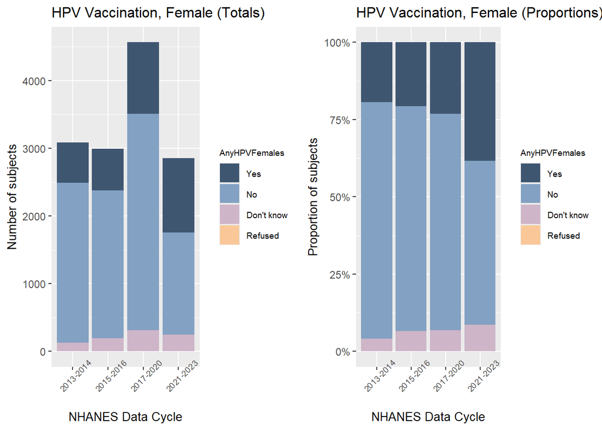

```r
hpvq1fem1 <- ggplot(data=subset(nhanes_hpv_eligible, !is.na(AnyHPVFemales)),
  aes(x = DataCycle, fill = AnyHPVFemales)) +
  geom_bar() +
  labs(title = "HPV Vaccination, Female (Totals)") +
  labs(x = "NHANES Data Cycle", y = "Number of subjects") +
  theme(title = element_text(size = 10),
        axis.text.x = element_text(angle = 45, size= 7),
        legend.title = element_text(size = 7),
        legend.text = element_text(size = 7)) +
  scale_fill_paletteer_d("ltc::ploen")
hpvq1fem2 <- ggplot(data=subset(nhanes_hpv_eligible, !is.na(AnyHPVFemales)),
  aes(x = DataCycle, fill = AnyHPVFemales)) +
  geom_bar(position = "fill") +
  labs(title = "HPV Vaccination, Female (Proportions)") +
  labs(x = "NHANES Data Cycle", y = "Proportion of subjects") +
  scale_y_continuous(labels = percent) +
  theme(title = element_text(size = 10),
        axis.text.x = element_text(angle = 45, size= 7),
        legend.title = element_text(size = 7),
        legend.text = element_text(size = 7)) +
  scale_fill_paletteer_d("ltc::ploen")
plot_grid(hpvq1fem1, hpvq1fem2, label_size = 3)
```

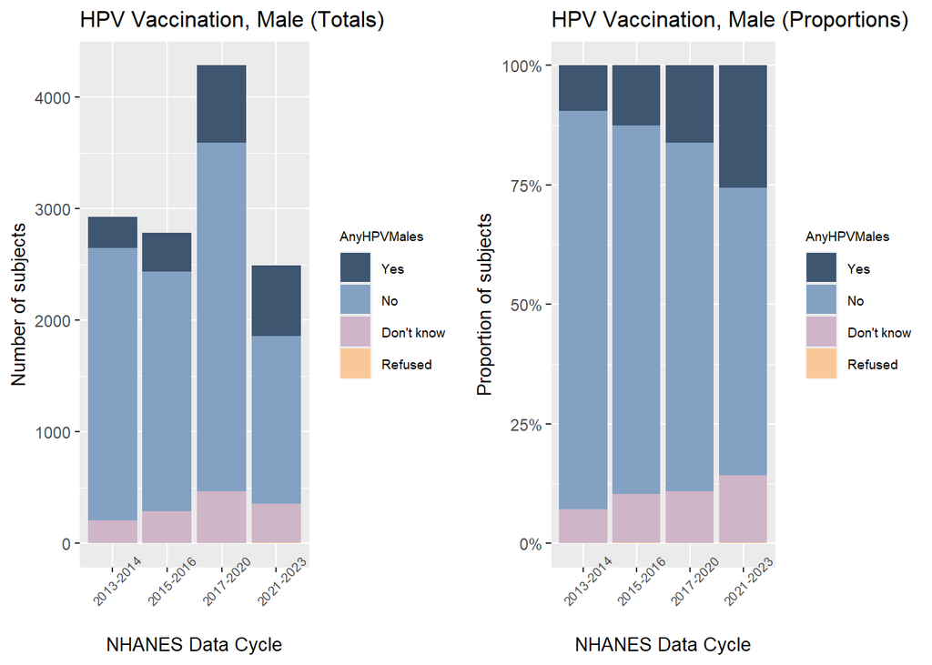

```r
hpvq1male1 <- ggplot(data=subset(nhanes_hpv_eligible, !is.na(AnyHPVMales)),
  aes(x = DataCycle, fill = AnyHPVMales)) +
  geom_bar() +
  labs(title = "HPV Vaccination, Male (Totals)") +
  labs(x = "NHANES Data Cycle", y = "Number of subjects") +
  theme(title = element_text(size = 10),
        axis.text.x = element_text(angle = 45, size= 7),
        legend.title = element_text(size = 7),
        legend.text = element_text(size = 7)) +
  scale_fill_paletteer_d("ltc::ploen")
hpvq1male2 <- ggplot(data=subset(nhanes_hpv_eligible, !is.na(AnyHPVMales)),
  aes(x = DataCycle, fill = AnyHPVMales)) +
  geom_bar(position = "fill") +
  labs(title = "HPV Vaccination, Male (Proportions)") +
  labs(x = "NHANES Data Cycle", y = "Proportion of subjects") +
  scale_y_continuous(labels = percent) +
  theme(title = element_text(size = 10),
        axis.text.x = element_text(angle = 45, size= 7),
        legend.title = element_text(size = 7),
        legend.text = element_text(size = 7)) +
  scale_fill_paletteer_d("ltc::ploen")
plot_grid(hpvq1male1, hpvq1male2, label_size = 5)
```

```r
# Removed NAs and used original male/female split variables to capture distributions of answers by sex group.

# Created bar plots for data on history of HPV vaccination by data cycle; created separate plots to show total subject numbers and proportions.  Separated into side-by-side bar plots for gender groups.
```

```r
levels(nhanes_hpv_eligible$AnyHPVShots)
```

```
[1] "No"  "Yes"
```

```r
levels(nhanes2013$AnyHPVShots)
```

```
[1] "No"  "Yes"
```

```r
levels(nhanes2021$AnyHPVShots)
```

```
[1] "No"  "Yes"
```

```r
# Checked levels to confirm "Yes" answer to HPV vaccination history is the independent outcome being analyzed.

summary((glm(AnyHPVShots ~ Gender, data = nhanes2013, family = binomial())))
```

```
Call:
glm(formula = AnyHPVShots ~ Gender, family = binomial(), data = nhanes2013)

Coefficients:
             Estimate Std. Error z value Pr(>|z|)
(Intercept)  -2.17656    0.06340  -34.33   <2e-16 ***
GenderFemale  0.80580    0.07816   10.31   <2e-16 ***
---
Signif. codes:  0 '***' 0.001 '**' 0.01 '*' 0.05 '.' 0.1 ' ' 1

(Dispersion parameter for binomial family taken to be 1)

    Null deviance: 4888.5  on 5681  degrees of freedom
Residual deviance: 4775.9  on 5680  degrees of freedom
  (4493 observations deleted due to missingness)
AIC: 4779.9

Number of Fisher Scoring iterations: 4
```

```r
summary((glm(AnyHPVShots ~ Gender, data = nhanes2015, family = binomial())))
```

```
Call:
glm(formula = AnyHPVShots ~ Gender, family = binomial(), data = nhanes2015)

Coefficients:
             Estimate Std. Error z value Pr(>|z|)
(Intercept)  -1.82056    0.05778 -31.507  < 2e-16 ***
GenderFemale  0.55905    0.07359   7.597 3.03e-14 ***
---
Signif. codes:  0 '***' 0.001 '**' 0.01 '*' 0.05 '.' 0.1 ' ' 1

(Dispersion parameter for binomial family taken to be 1)

    Null deviance: 5031.8  on 5296  degrees of freedom
Residual deviance: 4972.4  on 5295  degrees of freedom
  (4674 observations deleted due to missingness)
AIC: 4976.4

Number of Fisher Scoring iterations: 4
```

```r
summary((glm(AnyHPVShots ~ Gender, data = nhanes2017, family = binomial())))
```

```
Call:
glm(formula = AnyHPVShots ~ Gender, family = binomial(), data = nhanes2017)

Coefficients:
             Estimate Std. Error z value Pr(>|z|)
(Intercept)  -1.50200    0.04194 -35.810  < 2e-16 ***
GenderFemale  0.39805    0.05492   7.247 4.25e-13 ***
---
Signif. codes:  0 '***' 0.001 '**' 0.01 '*' 0.05 '.' 0.1 ' ' 1

(Dispersion parameter for binomial family taken to be 1)

    Null deviance: 8449.3  on 8068  degrees of freedom
Residual deviance: 8396.0  on 8067  degrees of freedom
  (7491 observations deleted due to missingness)
AIC: 8400

Number of Fisher Scoring iterations: 4
```

```r
summary((glm(AnyHPVShots ~ Gender, data = nhanes2021, family = binomial())))
```

```
Call:
glm(formula = AnyHPVShots ~ Gender, family = binomial(), data = nhanes2021)

Coefficients:
             Estimate Std. Error z value Pr(>|z|)
(Intercept)  -0.85645    0.04729 -18.110   <2e-16 ***
GenderFemale  0.53377    0.06173   8.646   <2e-16 ***
---
Signif. codes:  0 '***' 0.001 '**' 0.01 '*' 0.05 '.' 0.1 ' ' 1

(Dispersion parameter for binomial family taken to be 1)

    Null deviance: 6226.9  on 4743  degrees of freedom
Residual deviance: 6150.9  on 4742  degrees of freedom
  (7189 observations deleted due to missingness)
AIC: 6154.9

Number of Fisher Scoring iterations: 4
```

```r
# Ran logistic regression models using combined variable as outcome and Gender as predictor; ran for each NHANES cycle individually.
```